# BayesTestStreak Package

Author

Jim Albert

Published

July 20, 2025

This is an introduction to the functions in the `BayesTestStreak` R package. A general reference to the exploration of streakiness in sequences of binary response data can be found at https://bayesball.github.io/BLOG/Streaky.html

## Installation

One can install the `BayesTestStreak` package from my Github site:

```
remotes::install_github("bayesball/BayesTestStreak")
```

Once the package is installed, it can be loaded by the `library()` function.

```r
library(BayesTestStreak)
```

## Collect Some Streak Data

Let’s focus on hitting streak patterns of the 2016 Jose Abreu. Retrosheet data from the 2016 baseball season is available in the dataset `pbp2016` in the package.

We first find Abreu’s Retrosheet id by use of the `find_id()` function.

```r
(ja_id <- find_id("Jose Abreu"))
```

```
[1] "abrej003"
```

The `streak_data()` function will create the streak data for this exercise. The inputs are the batter id, the Retrosheet play-by-play data, the indication of a “success” (here “H” for hit), and “AB = TRUE” indicates we will only consider at-bats.

```r
ja_data <- streak_data(ja_id, pbp2016, "H", AB = TRUE)
head(ja_data)
```

```
    BAT_ID N      GAME_ID INN_CT Outcome
1 abrej003 1 OAK201604040      3       1
2 abrej003 2 OAK201604040      5       0
3 abrej003 3 OAK201604040      7       0
4 abrej003 4 OAK201604050      1       1
5 abrej003 5 OAK201604050      4       0
6 abrej003 6 OAK201604050      5       0
```

In the data frame `ja_data`, there are two key variables – `N` is the at-bat number and `Outcome` indicates if there is a hit (1) or an out (0).

## Plot the Data

A basic rug plot of the occurrences of hits can be producted by the `plot_streak_data()` function.

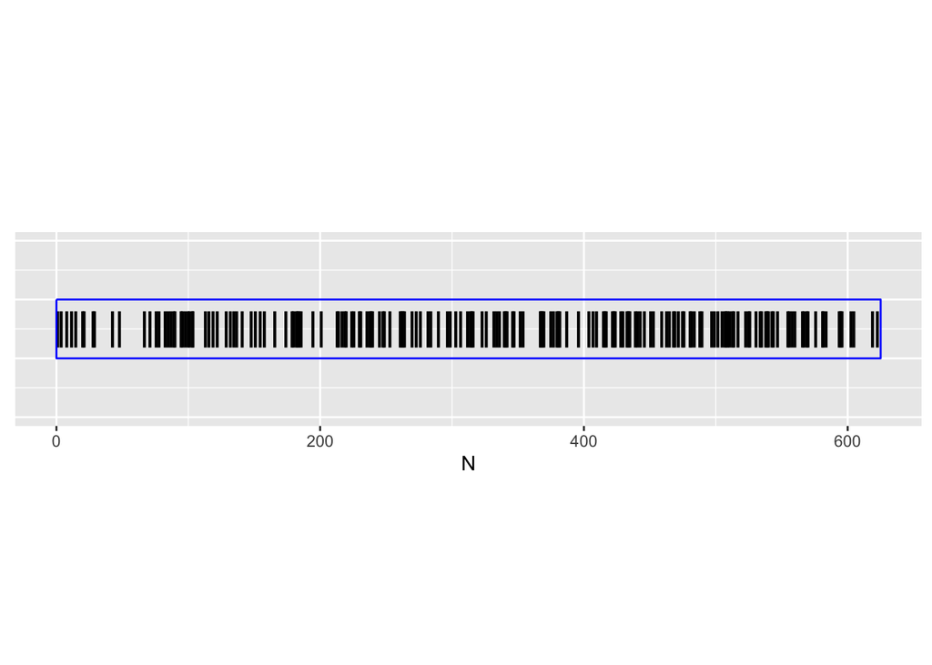

```r
plot_streak_data(ja_data)
```

## Moving Averages

One way to visualize the streaky patterns in the hit/out data is by use of a moving average plot.

The `moving_average()` function will compute moving batting averages using a width of 20 at-bats.

```r
ja_ma <- moving_average(ja_data, width = 20)
head(ja_ma)
```

```
    BAT_ID N      GAME_ID INN_CT Outcome Index Average       AVG
1 abrej003 1 OAK201604040      3       1    NA      NA 0.2932692
2 abrej003 2 OAK201604040      5       0    NA      NA 0.2932692
3 abrej003 3 OAK201604040      7       0    NA      NA 0.2932692
4 abrej003 4 OAK201604050      1       1    NA      NA 0.2932692
5 abrej003 5 OAK201604050      4       0    NA      NA 0.2932692
6 abrej003 6 OAK201604050      5       0    NA      NA 0.2932692
```

The `moving_average_plot()` function takes the moving averages data frame as input and produces a graph of these averages.

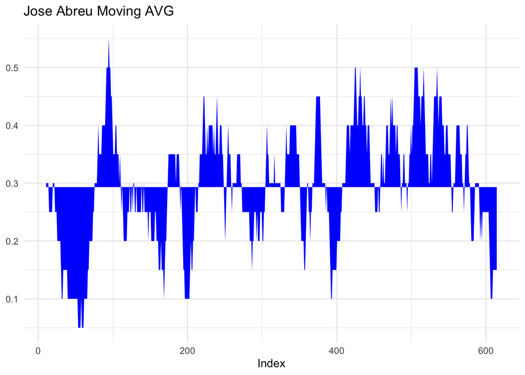

```r
moving_average_plot(ja_ma) +
  ggtitle("Jose Abreu Moving AVG")
```

## Spacings

The `find_spacings()` function will find all spacings (number of at-bats between consecutive hits). The output is a data frame of the spacings.

```r
ja_sp <- find_spacings(ja_data)
head(ja_sp)
```

```
  N Spacing
1 1       2
2 2       3
3 3       3
4 4       2
5 5       4
6 6       6
```

If the hit data are independent Bernouli random variables with a constant hitting probability, then the spacings will be independent Geometric distributed. One can graphically check if the spacings are Geometric by the use of a Geometric probability plot. If the points line up along a straight line, then the Geometric assumption is reasonable.

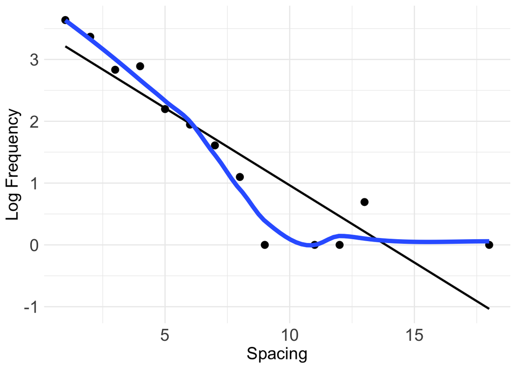

```r
geometric_plot(ja_sp)
```

## Permutation Test

A more formal approach to testing streakiness is by use of a permutation test. One runs this test by the `permutation_test()` function where the input is the streak data.

```r
permutation_test(ja_data)
```

```
[1] 0.516
```

A p-value close to 0 would indicate some support for streakiness. Here that is not the case.

## Bayesian Test

Another way of testing for streakiness is a Bayes factor that measures the support of a streaky model over a consistent model. The streaky model is indexed by a log K parameter and the function `bayes_factor_logK()` computes the log Bayes factor for a range of values of log K.

```r
out <- bayes_factor_logK(ja_data)
head(out)
```

```
  log_K    log_BF
1   1.0 -25.59440
2   1.1 -23.01366
3   1.2 -20.64765
4   1.3 -18.48361
5   1.4 -16.50907
6   1.5 -14.71188
```

The log Bayes factor values are graphed below. Since the log Bayes factors are negative for all log K values, there is little evidence supporting the streaky model.

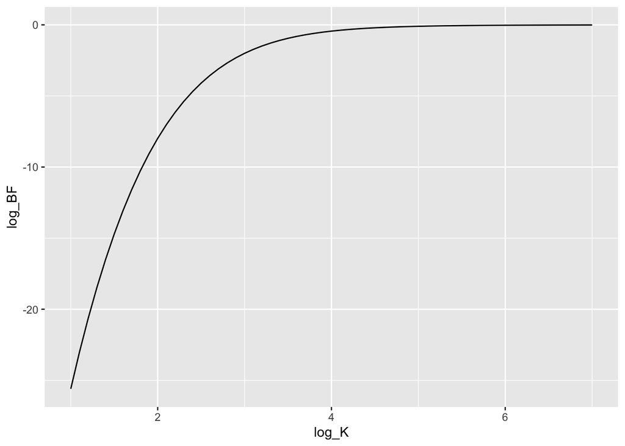

```r
ggplot(out, aes(log_K, log_BF)) +
  geom_line()
```